# Earthquakes package

Alexey V. Popov

2017-04-24

## Earthquakes package

Earthquakes package contains a few functions one can use to clean and visualize data about earthquake from [NOAA database](https://www.ngdc.noaa.gov/nndc/struts/form?t=101650&s=1&d=1).

First main function is *geom_timeline()*. It makes a ggplot geom object representing timeline within defined limits with earthquakes.

Second main function is *eq_map()*. It makes a interactive map with earthquakes epicentrum and popup information.

There are a few data cleaning and processing function. See details below.

## Data

All functions works with data from [NOAA earthquakes database](https://www.ngdc.noaa.gov/nndc/struts/form?t=101650&s=1&d=1) presented by: National Geophysical Data Center / World Data Service (NGDC/WDS): Significant Earthquake Database. National Geophysical Data Center, NOAA. doi:10.7289/V5TD9V7K

Package contains either raw data valid on 2017.04.23 and cleaned up sample.

Raw data can be accessed in the following way:

```r
  require(readr)
  filename <- system.file("extdata", "earthquakes.tsv.gz", package = "earthquakes")
  raw_data <- readr::read_delim(filename, delim = "\t")
```

Cleaned up sample is stored in *tbl_df data.frame* **earthquakes** (same name as package name) and can be accessed directly when package is loaded:

```r
 require(earthquakes)
 head(earthquakes)
```

```
## # A tibble: 6 × 48
##     I_D FLAG_TSUNAMI  YEAR MONTH   DAY  HOUR MINUTE SECOND FOCAL_DEPTH
##   <int>        <chr> <int> <int> <int> <int>  <int>  <chr>       <int>
## 1  7896         <NA>    46    10    23    NA     NA   <NA>          NA
## 2  7897         <NA>   128     2    23    NA     NA   <NA>          NA
## 3    66         <NA>   138     3     1    NA     NA   <NA>          NA
## 4  7900         <NA>   319     6    17    NA     NA   <NA>          NA
## 5   125         <NA>   512     5    21    NA     NA   <NA>          NA
## 6   158         <NA>   649     9    12    NA     NA   <NA>          NA
## # ... with 39 more variables: EQ_PRIMARY <dbl>, EQ_MAG_MW <chr>,
## #   EQ_MAG_MS <dbl>, EQ_MAG_MB <chr>, EQ_MAG_ML <dbl>, EQ_MAG_MFA <chr>,
## #   EQ_MAG_UNK <chr>, INTENSITY <int>, COUNTRY <chr>, STATE <chr>,
## #   LOCATION_NAME <chr>, LATITUDE <dbl>, LONGITUDE <dbl>,
## #   REGION_CODE <int>, DEATHS <dbl>, DEATHS_DESCRIPTION <int>,
## #   MISSING <chr>, MISSING_DESCRIPTION <int>, INJURIES <chr>,
## #   INJURIES_DESCRIPTION <int>, DAMAGE_MILLIONS_DOLLARS <chr>,
## #   DAMAGE_DESCRIPTION <int>, HOUSES_DESTROYED <int>,
## #   HOUSES_DESTROYED_DESCRIPTION <int>, HOUSES_DAMAGED <int>,
## #   HOUSES_DAMAGED_DESCRIPTION <int>, TOTAL_DEATHS <chr>,
## #   TOTAL_DEATHS_DESCRIPTION <int>, TOTAL_MISSING <chr>,
## #   TOTAL_MISSING_DESCRIPTION <chr>, TOTAL_INJURIES <int>,
## #   TOTAL_INJURIES_DESCRIPTION <int>, TOTAL_DAMAGE_MILLIONS_DOLLARS <chr>,
## #   TOTAL_DAMAGE_DESCRIPTION <int>, TOTAL_HOUSES_DESTROYED <int>,
## #   TOTAL_HOUSES_DESTROYED_DESCRIPTION <int>, TOTAL_HOUSES_DAMAGED <int>,
## #   TOTAL_HOUSES_DAMAGED_DESCRIPTION <int>, DATE <date>
```

```r
 str(earthquakes)
```

```
## Classes 'tbl_df', 'tbl' and 'data.frame':    971 obs. of  48 variables:
##  $ I_D                               : int  7896 7897 66 7900 125 158 162 5894 5895 169 ...
##  $ FLAG_TSUNAMI                      : chr  NA NA NA NA ...
##  $ YEAR                              : int  46 128 138 319 512 649 684 701 704 734 ...
##  $ MONTH                             : int  10 2 3 6 5 9 11 5 8 3 ...
##  $ DAY                               : int  23 23 1 17 21 12 29 12 2 19 ...
##  $ HOUR                              : int  NA NA NA NA NA NA NA NA NA NA ...
##  $ MINUTE                            : int  NA NA NA NA NA NA NA NA NA NA ...
##  $ SECOND                            : chr  NA NA NA NA ...
##  $ FOCAL_DEPTH                       : int  NA NA NA NA NA NA NA NA NA NA ...
##  $ EQ_PRIMARY                        : num  6.5 6.5 6.8 4.5 7.5 5.5 8.4 7 7 7 ...
##  $ EQ_MAG_MW                         : chr  NA NA NA NA ...
##  $ EQ_MAG_MS                         : num  6.5 6.5 6.8 4.5 7.5 5.5 8.4 7 7 7 ...
##  $ EQ_MAG_MB                         : chr  NA NA NA NA ...
##  $ EQ_MAG_ML                         : num  NA NA NA NA NA NA NA NA NA NA ...
```

[output cut: 34 more lines]

## Functions

### Make a time line geom *geom_timeline()*

geom_timeline() makes a ggplot2::Geom which plots a time line of earthquakes ranging from xmin to xmaxdates with a point for each earthquake. Optional aesthetics include color, size, and alpha (for transparency). The xaesthetic is a date and an optional y aesthetic is a factor indicating some stratification in which case multiple time lines will be plotted for each level of the factor (e.g. country).

User must specify the following parameters:

- **data** - Earthquake data in the dataframe in format of NOAA earthquakes database (Dataframe), mandatory.
- **xmindate** as aes parameter: Minimal date of the considering time frame (Date), mandatory.
- **xmaxdate** as aes parameter: Maximum date of the considering time frame (Date), mandatory.
- **event_date** as aes parameter: date of earthquake, usually name of the column in data (Date), mandatory.
- **richter** as aes parameter: Richter`s magnitude of earthquakes, usually name of the column in data (numeric), mandatory.
- **death** as aes parameter: deaths produced by earthquakes, usually name of the column in data (numeric), mandatory.

Optional parameters:

- **colour** as aes parameter: main colour of earthquakes marks (colour name), optional
- **scale** as aes parameter: scale of earthquakes marks, coefficient (numeric), optional
- **transparency** as aes parameter: transparency of earthquakes marks (numeric, (0..1)), optional
- **layers** as aes parameter: groping of earthquakes marks by some parameters, e.g. COUNTRY, optional

Example of usage:

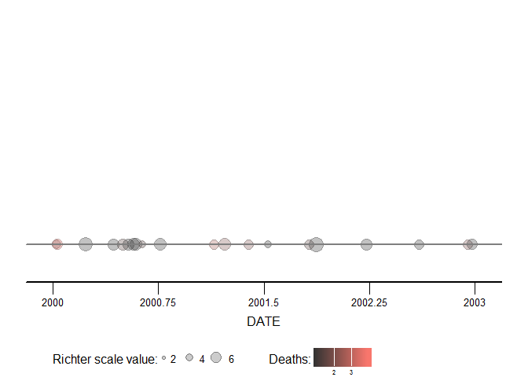

```r
 require(earthquakes)
 ggplot2::ggplot() +
   ggplot2::theme_void() +
   geom_timeline(data = earthquakes, ggplot2::aes(event_date = DATE,
                                   xmindate = 2000,
                                   xmaxdate = 2003,
                                   richter = EQ_PRIMARY,
                                   death = DEATHS,
                                   transparency = 0.3,
                                   colour = "red",
                                   scale = 0.5))+
   ggplot2::theme(legend.position="none")
```

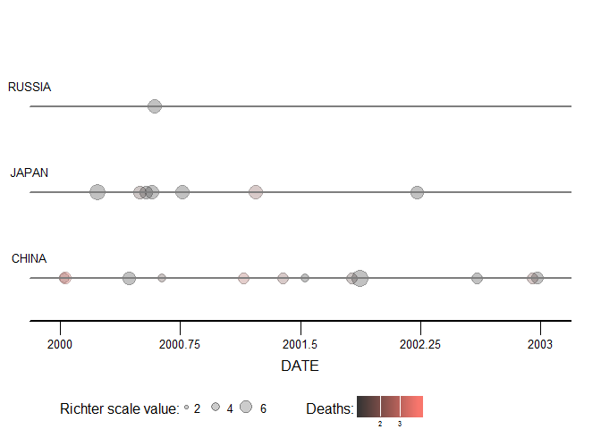

```r
 require(earthquakes)
 ggplot2::ggplot() +
   ggplot2::theme_void() +
   geom_timeline(data = earthquakes, ggplot2::aes(event_date = DATE,
                                   xmindate = 2000,
                                   xmaxdate = 2003,
                                   richter = EQ_PRIMARY,
                                   death = DEATHS,
                                   transparency = 0.3,
                                   colour = "red",
                                   scale = 0.5,
                                   layers = COUNTRY))+
   ggplot2::theme(legend.position="none")
```

### Make an annotation to timeline_geom

geom_timeline_label() function makes a ggplot2::Geom intended for adding annotations to the earthquake data. This geom adds a vertical line to each data point with a text annotation (e.g. the location of the earthquake) attached to each line. There is an option to subset to n_max number of earthquakes, where we take the n_max largest (by magnitude) earthquakes. Aesthetics are x, which is the date of the earthquake and label which takes the column name from which annotations will be obtained.

- **data** - Earthquake data in the dataframe in format of NOAA earthquakes database (Dataframe), mandatory.
- **xmindate** as aes parameter: Minimal date of the considering time frame (Date), mandatory.
- **xmaxdate** as aes parameter: Maximum date of the considering time frame (Date), mandatory.
- **event_date** as aes parameter: date of earthquake, usually name of the column in data (Date), mandatory.
- **richter** as aes parameter: Richter`s magnitude of earthquakes, usually name of the column in data (numeric), mandatory.
- **labels** as aes parameter: text labels of earthquakes, usually name of the column in data (character), mandatory.

Example of usage:

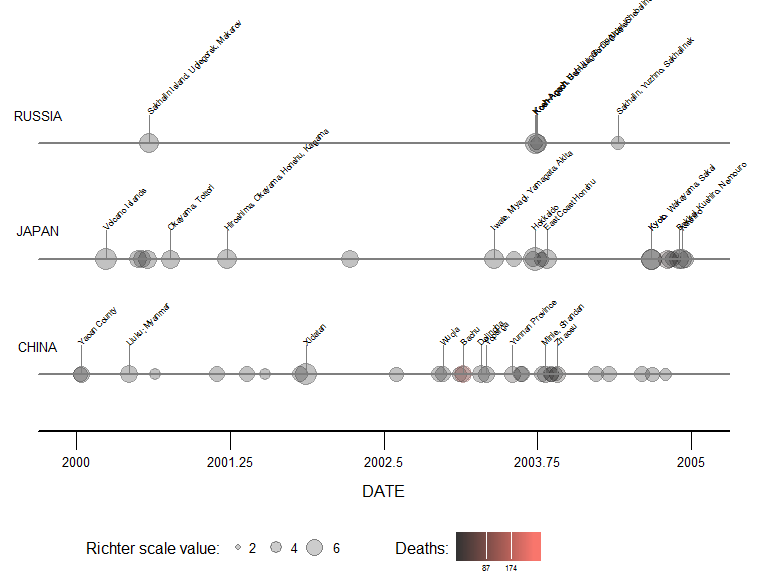

```r
 require(earthquakes)
   ggplot2::ggplot() +
   ggplot2::theme_void() +
   geom_timeline(data = earthquakes, ggplot2::aes(event_date = DATE,
                                   xmindate = 2000,
                                   xmaxdate = 2005,
                                   richter = EQ_PRIMARY,
                                   death = DEATHS,
                                   transparency = 0.3,
                                   colour = "red",
                                   scale = 0.5,
                                   layers = COUNTRY))+
   ggplot2::theme(legend.position="none") +
   geom_timeline_label(data = earthquakes, ggplot2::aes(event_date = DATE,
                                         xmindate = 2000,
                                         xmaxdate = 2005,
                                         richter = EQ_PRIMARY,
                                         layers = COUNTRY,
                                         labels = LOCATION_NAME))
```

### Cleaning data

Function *eq_clean_data()* takes raw NOAA data frame and returns a clean data frame. The clean data frame have the following:

- A date column created by uniting the year, month, day and converting it to the Date class
- LATITUDE and LONGITUDE columns converted to numeric class
- LOCATION cleaned up by *eq_location_clean()* (see below);
- data with no LONGITUDE or LATITUDE removed;
- data with no Richter magnitude removed;
- data with YEAR B.C. removed.

Function *eq_location_clean()* cleans the LOCATION_NAME column by stripping out the country name (including the colon) and converts names to title case (as opposed to all caps)

Functions *eq_clean_data()* and *eq_location_clean()* take one parameter only: *data* - raw earthquake data as dataframe in format of NOAA earthquakes database.

Examples:

```r
 require(earthquakes)
 filename <- system.file("extdata", "earthquakes.tsv.gz", package = "earthquakes")
 raw_data <- read_delim(filename, delim = "\t")
 data <- eq_location_clean(raw_data)
 head(data$LOCATION_NAME)
```

```
## [1] "Bab-a-Daraa,al-Karak"     "Ugarit"
## [3] "w"                        "Thera Island (Santorini)"
## [5] "Ariha (Jericho)"          "Lacus Cimini"
```

### Mapping data

Functions *eq_create_label()* takes one parameter only: *data* - raw earthquake data as dataframe in format of NOAA earthquakes database.

Example:

```r
require(earthquakes)
labels <- eq_create_label(earthquakes)
head(labels)
```

```
## [1] "<b>Location:</b> Nanyang"
## [2] "<b>Location:</b> Gangu"
## [3] "<b>Location:</b> Gansu Province"
## [4] "<b>Location:</b> Xihe"
## [5] "<b>Location:</b> Yingxian <br/> <b>Magnitude:</b> 7.5 <br/> <b>Deaths:</b> 5130 <br/>"
## [6] "<b>Location:</b> Linfen <br/> <b>Magnitude:</b> 5.5 <br/> <b>Deaths:</b> 50 <br/>"
```

Function *eq_map()* takes an argument data containing the filtered data frame with earthquakes to visualize. The function maps the epicenters (LATITUDE/LONGITUDE) and annotates each point with in pop up window containing annotation data stored in a column of the data frame. The user is able to choose which column is used for the annotation in the pop-up with a function argument named **annot_col**. Each earthquake is represented as a circle, and the radius of the circle is proportional to the earthquake’s magnitude (EQ_PRIMARY).

Function *eq_map()* takes two parameters: * *data* - raw earthquake data as dataframe in format of NOAA earthquakes database; * *annot_col* - column in data frame to use for annotation

Example:

```r
 require(earthquakes)

 filename <- system.file("extdata", "earthquakes.tsv.gz", package = "earthquakes")
 readr::read_delim(filename, delim = "\t") %>%
   eq_clean_data() %>%
   dplyr::filter(COUNTRY == "MEXICO" & as.integer(YEAR) >= 2000) %>%
   dplyr::mutate(popup_text = eq_create_label(.)) %>%
   eq_map(annot_col = "popup_text")
```

[interactive chart not shown]